# Process Mining Project - BPI Challenge 2018

Michele Biondi - 2019

## Understanding the problem of undesidered outcomes

A case is opened usually in May and should be closed by end of the year.

When this doesn't happen we have an undesidered outcome which could be:

- **Undesidered outcome 1**: The payment is late. A payment can be considered timely, if there has been a “begin payment” activity by the end of the year that was not eventually followed by “abort payment”.
- **Undesidered outcome 2**: The case needs to be reopened, either by the department (subprocess “Change”) or due to a legal objection by the applicant (subprocess “Objection”). This may result in additional payments or reimbursements (“payment_actual{x}“ > 0, where x ≥ 1 refers to the xth payment after the initial one)

The business **question** given is the following:  
We would like to detect such cases as early as possible. Ideally, this should happen before a decision is made for this case (first occurrence of “Payment application+application+decide”). You may use data from previous years to make predictions for the current year

Also it would be interesting to analyze the differences beetwen years and the various departmens (as of the last two business questions)

## Process discovery and analysis

[figure not shown]

This is the distribution of the events, the peaks we can observe are mainly from October to December of each year.

[figure not shown]

This is the active cases graph, most of the cases start around May/June and end in December, but as we can see there are some residual events every year.

[figure not shown]

Most of the cases require less than a year in total. The mean case duration is 43 weeks.

These are the total event log statistics:

[figure not shown]

The red arrows point to the Payment application-application part of the map, that is the most frequent activities. This is supported by setting the color schema to represent *Case frequency*, we can clearly see that all the darker coloured ones are part of this group (The darker the color the more frequent the activity)

[figure not shown]

These are the activities regarding *Objections*, they are useful in the understanding of Undesidered outcome 2.

[figure not shown]

These are the activities relative to the *Change* subprocess that are also useful in the study of Undesidered outcome 2. The remaining cells are relative to *Main* subprocess.

[figure not shown]

## Undesidered outcomes 1

To find out our undesidered outcomes 1 we just need 3 activities for each case: Application initialize, Begin payment and abort payment. A payment is late basically if the last activity is not a begin payment (So an abort or just initialized) or it is a begin payment but from a different year than the case year

```python
uo1_code = """
activities = ['Payment application-Application-initialize', 'Payment application-Application-begin payment', 'Payment application-Application-abort payment']

df_prepared = df[df['Activity'].isin(activities)]

cases = df_prepared['Case ID'].unique()

uo1_list = []

for case in cases:
    is_late = False

    case_df = df_prepared[df_prepared['Case ID'] == case]
    last_activity = case_df.tail(1)

    if last_activity['Activity'].item() != 'Payment application-Application-begin payment':
        # Last activity is initialize or abort payment
        is_late = True
    else:
        payment_dt = datetime.strptime(last_activity['Complete Timestamp'].item(), '%Y/%m/%d %H:%M:%S.%f')
        case_year = last_activity['(case) year']
        if payment_dt.year > case_year.item():
            is_late = True

    uo1_list.append((case, is_late))

uo1_df = pd.DataFrame(uo1_list, columns=['Case ID', 'Late Payment'])

uo1_df.to_csv('./data/uo1.csv', index=False)
"""
```

Now we will save the file and proceed to use RapidMiner to create predictions

```python
uo1_ready.to_csv('./data/uo1_ready.csv', index=False)
```

Let's take a look a more in depth look about late payments each year

[figure not shown]

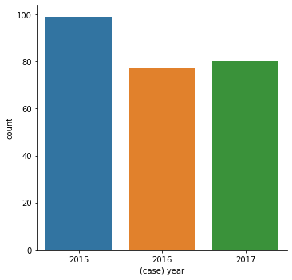

```python
sns.catplot(x="(case) year", kind="count", data=uo1_ready_t)
```

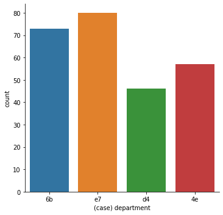

```python
sns.catplot(x="(case) department", kind="count", data=uo1_ready_t)
```

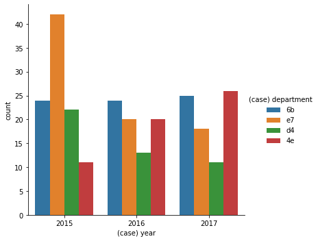

```python
sns.catplot(x="(case) year", hue="(case) department", kind="count", data=uo1_ready_t);
```

```python
uo1_ready_t['(case) department'].value_counts(normalize=True)
```

```
e7    0.312500
6b    0.285156
4e    0.222656
d4    0.179688
Name: (case) department, dtype: float64
```

```python
uo1_ready_t[uo1_ready_t['(case) year'] == 2015]['(case) department'].value_counts(normalize=True)
```

```
e7    0.424242
6b    0.242424
d4    0.222222
4e    0.111111
Name: (case) department, dtype: float64
```

```python
uo1_ready_t[uo1_ready_t['(case) year'] == 2016]['(case) department'].value_counts(normalize=True)
```

```
6b    0.311688
e7    0.259740
4e    0.259740
d4    0.168831
Name: (case) department, dtype: float64
```

```python
uo1_ready_t[uo1_ready_t['(case) year'] == 2017]['(case) department'].value_counts(normalize=True)
```

```
4e    0.3250
6b    0.3125
e7    0.2250
d4    0.1375
Name: (case) department, dtype: float64
```

Applying some basic data cleaning and feature selection we end up with the following results:

[figure not shown]

The best model overall was Decision Tree and the model is the following:

[figure not shown]

## Undesidered outcome 2

To find undesidered outcome 2 we just need to check if the case has an objection or change activity. Also we can't use as predictors the payment_actual columns as they are calculated after the undesidered outcome. We also won't use 2017 data for training because we don't know if it will be changed or objected.

```python
subprocesses = ['Objection', 'Change']

filter_mask = df_no2017['subprocess'].isin(subprocesses)

df_objchg = df_no2017[filter_mask]

df_objchg_unique= df_objchg.drop_duplicates(subset='Case ID')
```

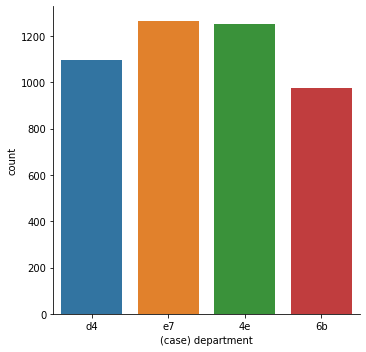

```python
sns.catplot(x="(case) department", kind="count", data=uo2_t)
```

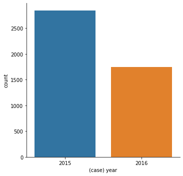

```python
sns.catplot(x="(case) year", kind="count", data=uo2_t)
```

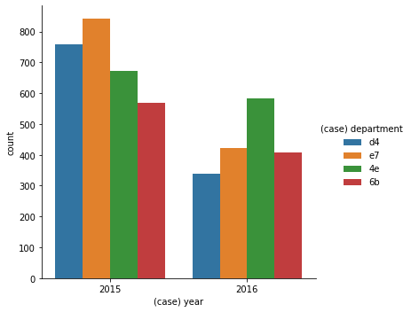

```python
sns.catplot(x="(case) year", hue="(case) department", kind="count", data=uo2_t);
```

```python
uo2_t['(case) department'].value_counts(normalize=True)
```

```
e7    0.275419
4e    0.273024
d4    0.238842
6b    0.212715
Name: (case) department, dtype: float64
```

```python
uo2_t[uo2_t['(case) year'] == 2016]['(case) department'].value_counts(normalize=True)
```

```
4e    0.332571
e7    0.241714
6b    0.232571
d4    0.193143
Name: (case) department, dtype: float64
```

```python
uo2_t[uo2_t['(case) year'] == 2015]['(case) department'].value_counts(normalize=True)
```

```
e7    0.296166
d4    0.266972
4e    0.236370
6b    0.200492
Name: (case) department, dtype: float64
```

These are the model results:

[figure not shown]

And these are the weights of the Generalized Linear model (which performed the best)

[figure not shown]

## CatBoost

We will also try the new cool kid in town, CatBoost, a decision-tree based algorithm developed by Yandex and open sourced as both a cli tool and Python/R package. The main difference between Catboost and other gradient-boosted tree algorithms is that it produces symmetric trees to increase prediction speed. It usually performs better when there are categorical variables (but beware of no free lunch theorem)

### Undesidered outcome 1

[figure not shown]

```python
model_uo1.get_feature_importance(prettified=True)
```

|  | Feature Id | Importances |
| --- | --- | --- |
| 0 | (case) payment_actual0 | 71.356235 |
| 1 | (case) penalty_amount0 | 7.980355 |
| 2 | (case) amount_applied0 | 6.863219 |
| 3 | (case) area | 2.839355 |
| 4 | (case) number_parcels | 1.878694 |
| 5 | (case) payment_actual1 | 1.716049 |
| 6 | (case) selected_manually | 1.711567 |
| 7 | (case) cross_compliance | 0.773441 |
| 8 | (case) amount_applied1 | 0.655858 |
| 9 | (case) penalty_AGP | 0.642386 |
| 10 | (case) department | 0.553712 |
| 11 | (case) small farmer | 0.497829 |
| 12 | (case) penalty_amount1 | 0.376056 |
| 13 | (case) payment_actual2 | 0.258029 |
| 14 | (case) penalty_B5 | 0.228573 |
| 15 | (case) penalty_GP1 | 0.169528 |
| 16 | (case) penalty_B2 | 0.166233 |
| 17 | (case) penalty_CC | 0.143149 |
| 18 | (case) penalty_BGK | 0.129979 |
| 19 | (case) penalty_JLP6 | 0.117416 |
| 20 | (case) penalty_B6 | 0.116267 |
| 21 | (case) penalty_amount2 | 0.112728 |
| 22 | (case) penalty_B3 | 0.093912 |
| 23 | (case) selected_random | 0.090868 |
| 24 | (case) penalty_C4 | 0.089056 |
| 25 | (case) amount_applied2 | 0.081205 |
| 26 | (case) redistribution | 0.073987 |
| 27 | (case) selected_risk | 0.065844 |
| 28 | (case) penalty_B16 | 0.062476 |
| 29 | (case) penalty_ABP | 0.053447 |
| 30 | (case) young farmer | 0.032554 |
| 31 | (case) penalty_JLP1 | 0.022608 |
| 32 | (case) penalty_V5 | 0.022219 |
| 33 | (case) penalty_AUVP | 0.014959 |
| 34 | (case) penalty_C9 | 0.007507 |
| 35 | (case) penalty_B4 | 0.002697 |
| 36 | (case) amount_applied3 | 0.000000 |
| 37 | (case) basic payment | 0.000000 |
| 38 | (case) greening | 0.000000 |
| 39 | (case) payment_actual3 | 0.000000 |
| 40 | (case) penalty_AJLP | 0.000000 |
| 41 | (case) penalty_AVBP | 0.000000 |
| 42 | (case) penalty_AVGP | 0.000000 |
| 43 | (case) penalty_AVJLP | 0.000000 |
| 44 | (case) penalty_AVUVP | 0.000000 |
| 45 | (case) penalty_B5F | 0.000000 |
| 46 | (case) penalty_BGKV | 0.000000 |
| 47 | (case) penalty_BGP | 0.000000 |
| 48 | (case) penalty_C16 | 0.000000 |
| 49 | (case) penalty_JLP2 | 0.000000 |
| 50 | (case) penalty_JLP3 | 0.000000 |
| 51 | (case) penalty_JLP5 | 0.000000 |
| 52 | (case) penalty_JLP7 | 0.000000 |
| 53 | (case) penalty_amount3 | 0.000000 |
| 54 | (case) program-id | 0.000000 |
| 55 | (case) risk_factor | 0.000000 |

### Undesidered outcome 2

[figure not shown]

```python
model_uo2.get_feature_importance(prettified=True)
```

|  | Feature Id | Importances |
| --- | --- | --- |
| 0 | (case) penalty_amount0 | 21.921050 |
| 1 | (case) department | 12.739642 |
| 2 | (case) area | 11.160233 |
| 3 | (case) amount_applied2 | 9.653843 |
| 4 | (case) number_parcels | 8.799736 |
| 5 | (case) amount_applied0 | 8.509067 |
| 6 | (case) payment_actual0 | 7.626850 |
| 7 | (case) penalty_amount2 | 4.990216 |
| 8 | (case) cross_compliance | 3.093945 |
| 9 | (case) penalty_B2 | 1.891292 |
| 10 | (case) rejected | 1.720342 |
| 11 | (case) penalty_CC | 1.686140 |
| 12 | (case) penalty_AUVP | 0.859467 |
| 13 | (case) selected_manually | 0.658785 |
| 14 | (case) penalty_GP1 | 0.555543 |
| 15 | (case) small farmer | 0.499585 |
| 16 | (case) penalty_JLP1 | 0.452632 |
| 17 | (case) penalty_BGK | 0.451944 |
| 18 | (case) penalty_B3 | 0.384294 |
| 19 | (case) penalty_B4 | 0.361432 |
| 20 | (case) penalty_AGP | 0.290843 |
| 21 | (case) selected_random | 0.245343 |
| 22 | (case) selected_risk | 0.233668 |
| 23 | (case) penalty_B6 | 0.221993 |
| 24 | (case) penalty_B5 | 0.141444 |
| 25 | (case) penalty_JLP2 | 0.131038 |
| 26 | (case) penalty_B16 | 0.122025 |
| 27 | (case) young farmer | 0.113754 |
| 28 | (case) penalty_C4 | 0.105277 |
| 29 | (case) penalty_ABP | 0.093123 |
| 30 | (case) amount_applied3 | 0.067746 |
| 31 | (case) penalty_amount3 | 0.056815 |
| 32 | (case) redistribution | 0.052787 |
| 33 | (case) penalty_AJLP | 0.048019 |
| 34 | (case) penalty_C9 | 0.028440 |
| 35 | (case) penalty_JLP6 | 0.015810 |
| 36 | (case) penalty_JLP3 | 0.010780 |
| 37 | (case) penalty_JLP5 | 0.002754 |
| 38 | (case) risk_factor | 0.002008 |
| 39 | (case) penalty_V5 | 0.000294 |
| 40 | (case) basic payment | 0.000000 |
| 41 | (case) greening | 0.000000 |
| 42 | (case) penalty_AVBP | 0.000000 |
| 43 | (case) penalty_AVGP | 0.000000 |
| 44 | (case) penalty_AVJLP | 0.000000 |
| 45 | (case) penalty_AVUVP | 0.000000 |
| 46 | (case) penalty_B5F | 0.000000 |
| 47 | (case) penalty_BGKV | 0.000000 |
| 48 | (case) penalty_BGP | 0.000000 |
| 49 | (case) penalty_C16 | 0.000000 |
| 50 | (case) penalty_JLP7 | 0.000000 |
| 51 | (case) program-id | 0.000000 |

We can at last try to predict undesidered outcomes 2 for year 2017.

These are the predictions:

```python
uo2_2017final['predictions'].value_counts()
```

```
0.0    10154
1.0     4353
Name: predictions, dtype: int64
```

In percentage:

```python
uo2_2017final['predictions'].value_counts(normalize=True)
```

```
0.0    0.699938
1.0    0.300062
Name: predictions, dtype: float64
```